# Исследование объявлений о продаже квартир

**Цель исследования:** установить параметры, влияющие на рыночную стоимость объектов недвижимости.

**Описание данных:** По каждой квартире на продажу доступны два вида данных. Первые вписаны пользователем, вторые — получены автоматически на основе картографических данных. Например, расстояние до центра, аэропорта, ближайшего парка и водоёма.

- airports_nearest — расстояние до ближайшего аэропорта в метрах (м)
- balcony — число балконов
- ceiling_height — высота потолков (м)
- cityCenters_nearest — расстояние до центра города (м)
- days_exposition — сколько дней было размещено объявление (от публикации до снятия)
- first_day_exposition — дата публикации
- floor — этаж
- floors_total — всего этажей в доме
- is_apartment — апартаменты (булев тип)
- kitchen_area — площадь кухни в квадратных метрах (м²)
- last_price — цена на момент снятия с публикации
- living_area — жилая площадь в квадратных метрах (м²)
- locality_name — название населённого пункта
- open_plan — свободная планировка (булев тип)
- parks_around3000 — число парков в радиусе 3 км
- parks_nearest — расстояние до ближайшего парка (м)
- ponds_around3000 — число водоёмов в радиусе 3 км
- ponds_nearest — расстояние до ближайшего водоёма (м)
- rooms — число комнат
- studio — квартира-студия (булев тип)
- total_area — общая площадь квартиры в квадратных метрах (м²)
- total_images — число фотографий квартиры в объявлении

**План работы:**

1. Изучить общую информацию. Построить гистограмму для всех числовых столбцов таблицы на одном графике.
2. Предобработка данных:
- определить пропуски и заполнить там, где это возможно
- рассмотреть типы данных в каждом столбце и преобразовать по необходимости
- работа с явными и неявными дубликатами
1. Дополнение таблицы стобцами, которые будут нужны в дальнейшей работе:
- цена одного квадратного метра;
- день недели публикации объявления (0 — понедельник, 1 — вторник и так далее);
- месяц публикации объявления;
- год публикации объявления;
- тип этажа квартиры (значения — «первый», «последний», «другой»);
- расстояние до центра города в километрах.
1. Исследовательский анализ данных:
- Изучить перечисленные ниже параметры объектов и построить отдельные гистограммы для каждого из этих параметров (общая площадь; жилая площадь; площадь кухни; цена объекта; количество комнат; высота потолков; тип этажа квартиры («первый», «последний», «другой»); общее количество этажей в доме; расстояние до центра города в метрах; расстояние до ближайшего парка).
- Изучить, как быстро продавались квартиры
- Изучить, зависит ли цена от: общей площади; жилой площади; площади кухни; количества комнат; этажа, на котором расположена квартира (первый, последний, другой); даты размещения (день недели, месяц, год).
- Посчитать среднюю цену одного квадратного метра в 10 населённых пунктах с наибольшим числом объявлений
- Описать, как стоимость объектов зависит от расстояния до центра Санкт-Петербурга

## шаг. Откройте файл с данными и изучите общую информацию.

```python
import pandas as pd
import matplotlib.pyplot as plt
```

```python
data = pd.read_csv('/datasets/real_estate_data.csv', sep='\t', parse_dates=['first_day_exposition'])
```

```python
def general_info(df):
    df.info()
    df.head(10)
    df.hist(figsize=(15, 20));
    df.duplicated()
    df = df.drop_duplicates().reset_index(drop=True)
    return df
```

```
<class 'pandas.core.frame.DataFrame'>
RangeIndex: 23699 entries, 0 to 23698
Data columns (total 22 columns):
 #   Column                Non-Null Count  Dtype
---  ------                --------------  -----
 0   total_images          23699 non-null  int64
 1   last_price            23699 non-null  float64
 2   total_area            23699 non-null  float64
 3   first_day_exposition  23699 non-null  datetime64[ns]
 4   rooms                 23699 non-null  int64
 5   ceiling_height        14504 non-null  float64
 6   floors_total          23613 non-null  float64
 7   living_area           21796 non-null  float64
 8   floor                 23699 non-null  int64
 9   is_apartment          2775 non-null   object
 10  studio                23699 non-null  bool
 11  open_plan             23699 non-null  bool
 12  kitchen_area          21421 non-null  float64
 13  balcony               12180 non-null  float64
 14  locality_name         23650 non-null  object
 15  airports_nearest      18157 non-null  float64
 16  cityCenters_nearest   18180 non-null  float64
 17  parks_around3000      18181 non-null  float64
 18  parks_nearest         8079 non-null   float64
 19  ponds_around3000      18181 non-null  float64
 20  ponds_nearest         9110 non-null   float64
 21  days_exposition       20518 non-null  float64
dtypes: bool(2), datetime64[ns](1), float64(14), int64(3), object(2)
memory usage: 3.7+ MB
```

|  | total_images | last_price | total_area | first_day_exposition | rooms | ceiling_height | floors_total | living_area | floor | is_apartment | ... | kitchen_area | balcony | locality_name | airports_nearest | cityCenters_nearest | parks_around3000 | parks_nearest | ponds_around3000 | ponds_nearest | days_exposition |
| --- | --- | --- | --- | --- | --- | --- | --- | --- | --- | --- | --- | --- | --- | --- | --- | --- | --- | --- | --- | --- | --- |
| 0 | 20 | 13000000.0 | 108.00 | 2019-03-07 | 3 | 2.70 | 16.0 | 51.0 | 8 | NaN | ... | 25.00 | NaN | Санкт-Петербург | 18863.0 | 16028.0 | 1.0 | 482.0 | 2.0 | 755.0 | NaN |
| 1 | 7 | 3350000.0 | 40.40 | 2018-12-04 | 1 | NaN | 11.0 | 18.6 | 1 | NaN | ... | 11.00 | 2.0 | посёлок Шушары | 12817.0 | 18603.0 | 0.0 | NaN | 0.0 | NaN | 81.0 |
| 2 | 10 | 5196000.0 | 56.00 | 2015-08-20 | 2 | NaN | 5.0 | 34.3 | 4 | NaN | ... | 8.30 | 0.0 | Санкт-Петербург | 21741.0 | 13933.0 | 1.0 | 90.0 | 2.0 | 574.0 | 558.0 |
| 3 | 0 | 64900000.0 | 159.00 | 2015-07-24 | 3 | NaN | 14.0 | NaN | 9 | NaN | ... | NaN | 0.0 | Санкт-Петербург | 28098.0 | 6800.0 | 2.0 | 84.0 | 3.0 | 234.0 | 424.0 |
| 4 | 2 | 10000000.0 | 100.00 | 2018-06-19 | 2 | 3.03 | 14.0 | 32.0 | 13 | NaN | ... | 41.00 | NaN | Санкт-Петербург | 31856.0 | 8098.0 | 2.0 | 112.0 | 1.0 | 48.0 | 121.0 |
| ... | ... | ... | ... | ... | ... | ... | ... | ... | ... | ... | ... | ... | ... | ... | ... | ... | ... | ... | ... | ... | ... |
| 23694 | 9 | 9700000.0 | 133.81 | 2017-03-21 | 3 | 3.70 | 5.0 | 73.3 | 3 | NaN | ... | 13.83 | NaN | Санкт-Петербург | 24665.0 | 4232.0 | 1.0 | 796.0 | 3.0 | 381.0 | NaN |
| 23695 | 14 | 3100000.0 | 59.00 | 2018-01-15 | 3 | NaN | 5.0 | 38.0 | 4 | NaN | ... | 8.50 | NaN | Тосно | NaN | NaN | NaN | NaN | NaN | NaN | 45.0 |
| 23696 | 18 | 2500000.0 | 56.70 | 2018-02-11 | 2 | NaN | 3.0 | 29.7 | 1 | NaN | ... | NaN | NaN | село Рождествено | NaN | NaN | NaN | NaN | NaN | NaN | NaN |
| 23697 | 13 | 11475000.0 | 76.75 | 2017-03-28 | 2 | 3.00 | 17.0 | NaN | 12 | NaN | ... | 23.30 | 2.0 | Санкт-Петербург | 39140.0 | 10364.0 | 2.0 | 173.0 | 3.0 | 196.0 | 602.0 |
| 23698 | 4 | 1350000.0 | 32.30 | 2017-07-21 | 1 | 2.50 | 5.0 | 12.3 | 1 | NaN | ... | 9.00 | NaN | поселок Новый Учхоз | NaN | NaN | NaN | NaN | NaN | NaN | NaN |

23699 rows × 22 columns

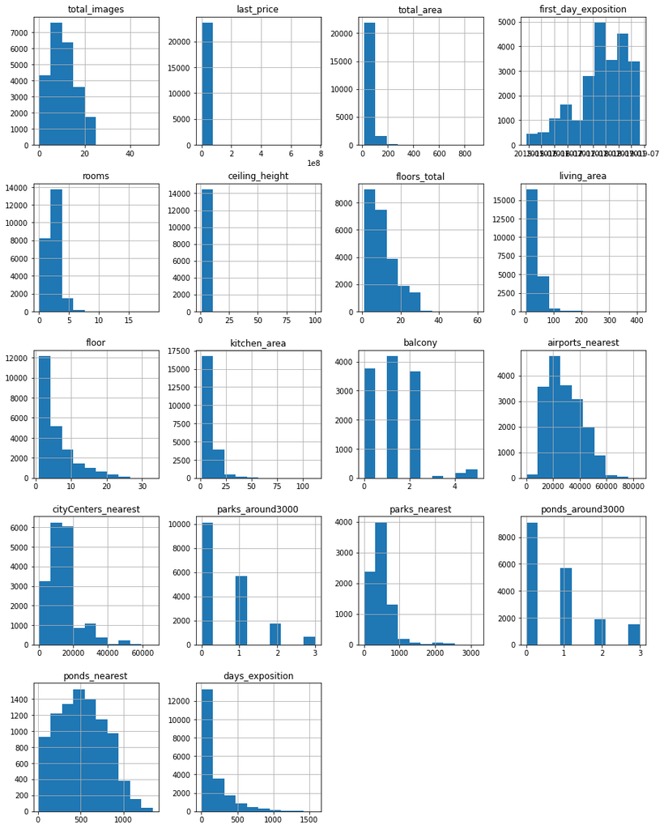

```python
general_info(data)
```

Посмотрели общую информацию, с типами данных в столбцах не всё в порядке. Займёмся этим на следующем шаге.

## шаг. Предобработка данных

Явных дубликатов не было, так как количество строк прежнее. Переходим к работе с типами данных в столбцах.

Менять типы данных я буду параллельно с работой с пропусками, чтобы сократить код. Проверяем пропуски.

```python
pd.DataFrame(round(data.isna().mean()*100,1)).style.background_gradient('coolwarm')
```

|  | 0 |
| --- | --- |
| total_images | 0.000000 |
| last_price | 0.000000 |
| total_area | 0.000000 |
| first_day_exposition | 0.000000 |
| rooms | 0.000000 |
| ceiling_height | 38.800000 |
| floors_total | 0.400000 |
| living_area | 8.000000 |
| floor | 0.000000 |
| is_apartment | 88.300000 |
| studio | 0.000000 |
| open_plan | 0.000000 |
| kitchen_area | 9.600000 |
| balcony | 48.600000 |
| locality_name | 0.200000 |
| airports_nearest | 23.400000 |
| cityCenters_nearest | 23.300000 |
| parks_around3000 | 23.300000 |
| parks_nearest | 65.900000 |
| ponds_around3000 | 23.300000 |
| ponds_nearest | 61.600000 |
| days_exposition | 13.400000 |

Итак у нас есть незначительное количество пропусков(<10%) по столбцам:living_area, locality_name, kitchen_area, floors_total. Их мы не будем заполнять.

Самое большое количество пропусков по is_apartment, логично предположить, что не отметили те, кто относит жильё к апартаментам, заполняем на false.

Пропуски по столбцу balcony также логично заполнить нулём.

Также много пропусков ceiling_height, заполнила медианой, так как это стандартизированная величина.

Большая проблема с данными собранными автоматически. Данные по аэропортам и паркам получены из геосервисов, поэтому приму пропуски за нулевые значения. То есть парков рядом нет. Расстояния же трогать не буду. Из них для нас явно важен параметр расстрояния до центра. Я не могу отбросить строки с пропусками, потому что это больше, чем пятая часть данных, но и заполнить тоже, потому что тогда я повлияю на результат. Поэтому оставляю нетронутым.

Как поменяю типы данных:

- last_price поменяла тип на int
- first_day_exposition поменяла тип на datetime без времени
- balcony поменяла тип на int
- parks_around3000 поменяла тип на int
- ponds_around3000 поменяла тип на int
- floors_total поменяла тип на int

```python
data['ceiling_height'].sort_values()
data['ceiling_height'].value_counts()
data['ceiling_height'].median()
data['ceiling_height'] = data['ceiling_height'].fillna(2.65)
```

Это странно, что за потолки в 1м, пока проигнорируем Сегодня минимальной нормой в России считается высота потолка 2,4 метра. Медианное значение 2.65 выглядит реальным, заполним пропуски им

```python
#решим, что не указали апартаменты там, где к ним и не относятся. заполним пропуски False
data['is_apartment'].value_counts()
data['is_apartment'] = data['is_apartment'].fillna(False)
```

```python
#время не указано, поэтому переведу в формат даты без времени
data['first_day_exposition'] = pd.to_datetime(data['first_day_exposition'], format = '%Y-%m-%d')
```

```python
data['balcony'] = data['balcony'].fillna(0)
data['balcony'] = data['balcony'].astype('int')
```

```python
data['last_price'] = data['last_price'].astype(int)
```

```python
data = data.dropna(subset=['floors_total'])
data['floors_total'] = data['floors_total'].astype(int)
```

Данные по аэропортам и паркам получены из геосервисов, поэтому приму пропуски за нулевые значения. То есть парков рядом нет. Расстояния же трогать не буду. Из них для нас явно важен параметр расстрояния до центра. Я не могу отбросить строки с пропусками, потому что это больше, чем пятая часть данных, но и заполнить тоже, потому что тогда я повлияю на результат. Поэтому оставляю нетронутым.

```python
data['parks_around3000'] = data['parks_around3000'].fillna(value=0).astype(int)
```

```python
data['ponds_around3000'] = data['ponds_around3000'].fillna(value=0).astype(int)
```

```python
data.isna().sum()
```

```
total_images                0
last_price                  0
total_area                  0
first_day_exposition        0
rooms                       0
ceiling_height              0
floors_total                0
living_area              1870
floor                       0
is_apartment                0
studio                      0
open_plan                   0
kitchen_area             2231
balcony                     0
locality_name              48
airports_nearest         5532
cityCenters_nearest      5509
parks_around3000            0
parks_nearest           15568
ponds_around3000            0
ponds_nearest           14552
days_exposition          3172
dtype: int64
```

```python
pd.DataFrame(round(data.isna().mean()*100,1)).style.background_gradient('coolwarm')
```

|  | 0 |
| --- | --- |
| total_images | 0.000000 |
| last_price | 0.000000 |
| total_area | 0.000000 |
| first_day_exposition | 0.000000 |
| rooms | 0.000000 |
| ceiling_height | 0.000000 |
| floors_total | 0.000000 |
| living_area | 7.900000 |
| floor | 0.000000 |
| is_apartment | 0.000000 |
| studio | 0.000000 |
| open_plan | 0.000000 |
| kitchen_area | 9.400000 |
| balcony | 0.000000 |
| locality_name | 0.200000 |
| airports_nearest | 23.400000 |
| cityCenters_nearest | 23.300000 |
| parks_around3000 | 0.000000 |
| parks_nearest | 65.900000 |
| ponds_around3000 | 0.000000 |
| ponds_nearest | 61.600000 |
| days_exposition | 13.400000 |

```python
data.info()
```

```
<class 'pandas.core.frame.DataFrame'>
Int64Index: 23613 entries, 0 to 23698
Data columns (total 22 columns):
 #   Column                Non-Null Count  Dtype
---  ------                --------------  -----
 0   total_images          23613 non-null  int64
 1   last_price            23613 non-null  int64
 2   total_area            23613 non-null  float64
 3   first_day_exposition  23613 non-null  datetime64[ns]
 4   rooms                 23613 non-null  int64
 5   ceiling_height        23613 non-null  float64
 6   floors_total          23613 non-null  int64
 7   living_area           21743 non-null  float64
 8   floor                 23613 non-null  int64
 9   is_apartment          23613 non-null  bool
 10  studio                23613 non-null  bool
 11  open_plan             23613 non-null  bool
 12  kitchen_area          21382 non-null  float64
 13  balcony               23613 non-null  int64
 14  locality_name         23565 non-null  object
 15  airports_nearest      18081 non-null  float64
 16  cityCenters_nearest   18104 non-null  float64
 17  parks_around3000      23613 non-null  int64
 18  parks_nearest         8045 non-null   float64
 19  ponds_around3000      23613 non-null  int64
 20  ponds_nearest         9061 non-null   float64
 21  days_exposition       20441 non-null  float64
dtypes: bool(3), datetime64[ns](1), float64(9), int64(8), object(1)
memory usage: 3.7+ MB
```

```python
data = data.apply(lambda x: x.replace({'поселок':'посёлок', 'городской посёлок': 'посёлок', 'посёлок городского типа': 'посёлок', 'коттеджный посёлок': 'посёлок', 'посёлок при железнодорожной станции': 'посёлок станции'}, regex=True))

len(data.locality_name.unique())
```

```
334
```

**Промежуточный вывод:** На данном этапе мы привели в порядок типы данных, заполнили пропуски, которые могут повлиять на работу, а также избавились от неявных дубликатов.

## шаг. Новые столбцы

Для дальнейшего анализа добавим столбец с ценой одного квадратного метра, округлим до двух знаков после запятой

```python
data['meter_price'] = data['last_price'] / data['living_area']
data['meter_price'] = round(data['meter_price'], 2)
data.head()
```

|  | total_images | last_price | total_area | first_day_exposition | rooms | ceiling_height | floors_total | living_area | floor | is_apartment | ... | balcony | locality_name | airports_nearest | cityCenters_nearest | parks_around3000 | parks_nearest | ponds_around3000 | ponds_nearest | days_exposition | meter_price |
| --- | --- | --- | --- | --- | --- | --- | --- | --- | --- | --- | --- | --- | --- | --- | --- | --- | --- | --- | --- | --- | --- |
| 0 | 20 | 13000000 | 108.0 | 2019-03-07 | 3 | 2.70 | 16 | 51.0 | 8 | False | ... | 0 | Санкт-Петербург | 18863.0 | 16028.0 | 1 | 482.0 | 2 | 755.0 | NaN | 254901.96 |
| 1 | 7 | 3350000 | 40.4 | 2018-12-04 | 1 | 2.65 | 11 | 18.6 | 1 | False | ... | 2 | посёлок Шушары | 12817.0 | 18603.0 | 0 | NaN | 0 | NaN | 81.0 | 180107.53 |
| 2 | 10 | 5196000 | 56.0 | 2015-08-20 | 2 | 2.65 | 5 | 34.3 | 4 | False | ... | 0 | Санкт-Петербург | 21741.0 | 13933.0 | 1 | 90.0 | 2 | 574.0 | 558.0 | 151486.88 |
| 3 | 0 | 64900000 | 159.0 | 2015-07-24 | 3 | 2.65 | 14 | NaN | 9 | False | ... | 0 | Санкт-Петербург | 28098.0 | 6800.0 | 2 | 84.0 | 3 | 234.0 | 424.0 | NaN |
| 4 | 2 | 10000000 | 100.0 | 2018-06-19 | 2 | 3.03 | 14 | 32.0 | 13 | False | ... | 0 | Санкт-Петербург | 31856.0 | 8098.0 | 2 | 112.0 | 1 | 48.0 | 121.0 | 312500.00 |

5 rows × 23 columns

Также добавим день недели публикации объявления (0 — понедельник, 1 — вторник и так далее);

```python
data['weekday'] = data['first_day_exposition'].dt.weekday
data.head()
```

|  | total_images | last_price | total_area | first_day_exposition | rooms | ceiling_height | floors_total | living_area | floor | is_apartment | ... | locality_name | airports_nearest | cityCenters_nearest | parks_around3000 | parks_nearest | ponds_around3000 | ponds_nearest | days_exposition | meter_price | weekday |
| --- | --- | --- | --- | --- | --- | --- | --- | --- | --- | --- | --- | --- | --- | --- | --- | --- | --- | --- | --- | --- | --- |
| 0 | 20 | 13000000 | 108.0 | 2019-03-07 | 3 | 2.70 | 16 | 51.0 | 8 | False | ... | Санкт-Петербург | 18863.0 | 16028.0 | 1 | 482.0 | 2 | 755.0 | NaN | 254901.96 | 3 |
| 1 | 7 | 3350000 | 40.4 | 2018-12-04 | 1 | 2.65 | 11 | 18.6 | 1 | False | ... | посёлок Шушары | 12817.0 | 18603.0 | 0 | NaN | 0 | NaN | 81.0 | 180107.53 | 1 |
| 2 | 10 | 5196000 | 56.0 | 2015-08-20 | 2 | 2.65 | 5 | 34.3 | 4 | False | ... | Санкт-Петербург | 21741.0 | 13933.0 | 1 | 90.0 | 2 | 574.0 | 558.0 | 151486.88 | 3 |
| 3 | 0 | 64900000 | 159.0 | 2015-07-24 | 3 | 2.65 | 14 | NaN | 9 | False | ... | Санкт-Петербург | 28098.0 | 6800.0 | 2 | 84.0 | 3 | 234.0 | 424.0 | NaN | 4 |
| 4 | 2 | 10000000 | 100.0 | 2018-06-19 | 2 | 3.03 | 14 | 32.0 | 13 | False | ... | Санкт-Петербург | 31856.0 | 8098.0 | 2 | 112.0 | 1 | 48.0 | 121.0 | 312500.00 | 1 |

5 rows × 24 columns

И столбцы с годом и месяцям публикации объявления;

```python
data['month'] = pd.DatetimeIndex(data['first_day_exposition']).month
data.head()
```

|  | total_images | last_price | total_area | first_day_exposition | rooms | ceiling_height | floors_total | living_area | floor | is_apartment | ... | airports_nearest | cityCenters_nearest | parks_around3000 | parks_nearest | ponds_around3000 | ponds_nearest | days_exposition | meter_price | weekday | month |
| --- | --- | --- | --- | --- | --- | --- | --- | --- | --- | --- | --- | --- | --- | --- | --- | --- | --- | --- | --- | --- | --- |
| 0 | 20 | 13000000 | 108.0 | 2019-03-07 | 3 | 2.70 | 16 | 51.0 | 8 | False | ... | 18863.0 | 16028.0 | 1 | 482.0 | 2 | 755.0 | NaN | 254901.96 | 3 | 3 |
| 1 | 7 | 3350000 | 40.4 | 2018-12-04 | 1 | 2.65 | 11 | 18.6 | 1 | False | ... | 12817.0 | 18603.0 | 0 | NaN | 0 | NaN | 81.0 | 180107.53 | 1 | 12 |
| 2 | 10 | 5196000 | 56.0 | 2015-08-20 | 2 | 2.65 | 5 | 34.3 | 4 | False | ... | 21741.0 | 13933.0 | 1 | 90.0 | 2 | 574.0 | 558.0 | 151486.88 | 3 | 8 |
| 3 | 0 | 64900000 | 159.0 | 2015-07-24 | 3 | 2.65 | 14 | NaN | 9 | False | ... | 28098.0 | 6800.0 | 2 | 84.0 | 3 | 234.0 | 424.0 | NaN | 4 | 7 |
| 4 | 2 | 10000000 | 100.0 | 2018-06-19 | 2 | 3.03 | 14 | 32.0 | 13 | False | ... | 31856.0 | 8098.0 | 2 | 112.0 | 1 | 48.0 | 121.0 | 312500.00 | 1 | 6 |

5 rows × 25 columns

```python
data['year'] = pd.DatetimeIndex(data['first_day_exposition']).year
data.head()
```

|  | total_images | last_price | total_area | first_day_exposition | rooms | ceiling_height | floors_total | living_area | floor | is_apartment | ... | cityCenters_nearest | parks_around3000 | parks_nearest | ponds_around3000 | ponds_nearest | days_exposition | meter_price | weekday | month | year |
| --- | --- | --- | --- | --- | --- | --- | --- | --- | --- | --- | --- | --- | --- | --- | --- | --- | --- | --- | --- | --- | --- |
| 0 | 20 | 13000000 | 108.0 | 2019-03-07 | 3 | 2.70 | 16 | 51.0 | 8 | False | ... | 16028.0 | 1 | 482.0 | 2 | 755.0 | NaN | 254901.96 | 3 | 3 | 2019 |
| 1 | 7 | 3350000 | 40.4 | 2018-12-04 | 1 | 2.65 | 11 | 18.6 | 1 | False | ... | 18603.0 | 0 | NaN | 0 | NaN | 81.0 | 180107.53 | 1 | 12 | 2018 |
| 2 | 10 | 5196000 | 56.0 | 2015-08-20 | 2 | 2.65 | 5 | 34.3 | 4 | False | ... | 13933.0 | 1 | 90.0 | 2 | 574.0 | 558.0 | 151486.88 | 3 | 8 | 2015 |
| 3 | 0 | 64900000 | 159.0 | 2015-07-24 | 3 | 2.65 | 14 | NaN | 9 | False | ... | 6800.0 | 2 | 84.0 | 3 | 234.0 | 424.0 | NaN | 4 | 7 | 2015 |
| 4 | 2 | 10000000 | 100.0 | 2018-06-19 | 2 | 3.03 | 14 | 32.0 | 13 | False | ... | 8098.0 | 2 | 112.0 | 1 | 48.0 | 121.0 | 312500.00 | 1 | 6 | 2018 |

5 rows × 26 columns

Этажей очень много, сгруппируем их по типам «первый», «последний», «другой»;

```python
def floor_group(row):
    floors_total = row['floors_total']
    floor = row['floor']
    if floor == 1:
        return 'первый'
    elif floor == floors_total:
        return 'последний'
    else:
        return 'другой'
```

```python
data['floor_group'] = data.apply(floor_group, axis = 1)
data.head()
```

|  | total_images | last_price | total_area | first_day_exposition | rooms | ceiling_height | floors_total | living_area | floor | is_apartment | ... | parks_around3000 | parks_nearest | ponds_around3000 | ponds_nearest | days_exposition | meter_price | weekday | month | year | floor_group |
| --- | --- | --- | --- | --- | --- | --- | --- | --- | --- | --- | --- | --- | --- | --- | --- | --- | --- | --- | --- | --- | --- |
| 0 | 20 | 13000000 | 108.0 | 2019-03-07 | 3 | 2.70 | 16 | 51.0 | 8 | False | ... | 1 | 482.0 | 2 | 755.0 | NaN | 254901.96 | 3 | 3 | 2019 | другой |
| 1 | 7 | 3350000 | 40.4 | 2018-12-04 | 1 | 2.65 | 11 | 18.6 | 1 | False | ... | 0 | NaN | 0 | NaN | 81.0 | 180107.53 | 1 | 12 | 2018 | первый |
| 2 | 10 | 5196000 | 56.0 | 2015-08-20 | 2 | 2.65 | 5 | 34.3 | 4 | False | ... | 1 | 90.0 | 2 | 574.0 | 558.0 | 151486.88 | 3 | 8 | 2015 | другой |
| 3 | 0 | 64900000 | 159.0 | 2015-07-24 | 3 | 2.65 | 14 | NaN | 9 | False | ... | 2 | 84.0 | 3 | 234.0 | 424.0 | NaN | 4 | 7 | 2015 | другой |
| 4 | 2 | 10000000 | 100.0 | 2018-06-19 | 2 | 3.03 | 14 | 32.0 | 13 | False | ... | 2 | 112.0 | 1 | 48.0 | 121.0 | 312500.00 | 1 | 6 | 2018 | другой |

5 rows × 27 columns

Также добавим столбец с расстоянием до центра города в километрах

```python
data['city_centers_km'] = round(data['cityCenters_nearest']/1000)
data.head(10)
```

|  | total_images | last_price | total_area | first_day_exposition | rooms | ceiling_height | floors_total | living_area | floor | is_apartment | ... | parks_nearest | ponds_around3000 | ponds_nearest | days_exposition | meter_price | weekday | month | year | floor_group | city_centers_km |
| --- | --- | --- | --- | --- | --- | --- | --- | --- | --- | --- | --- | --- | --- | --- | --- | --- | --- | --- | --- | --- | --- |
| 0 | 20 | 13000000 | 108.00 | 2019-03-07 | 3 | 2.70 | 16 | 51.00 | 8 | False | ... | 482.0 | 2 | 755.0 | NaN | 254901.96 | 3 | 3 | 2019 | другой | 16.0 |
| 1 | 7 | 3350000 | 40.40 | 2018-12-04 | 1 | 2.65 | 11 | 18.60 | 1 | False | ... | NaN | 0 | NaN | 81.0 | 180107.53 | 1 | 12 | 2018 | первый | 19.0 |
| 2 | 10 | 5196000 | 56.00 | 2015-08-20 | 2 | 2.65 | 5 | 34.30 | 4 | False | ... | 90.0 | 2 | 574.0 | 558.0 | 151486.88 | 3 | 8 | 2015 | другой | 14.0 |
| 3 | 0 | 64900000 | 159.00 | 2015-07-24 | 3 | 2.65 | 14 | NaN | 9 | False | ... | 84.0 | 3 | 234.0 | 424.0 | NaN | 4 | 7 | 2015 | другой | 7.0 |
| 4 | 2 | 10000000 | 100.00 | 2018-06-19 | 2 | 3.03 | 14 | 32.00 | 13 | False | ... | 112.0 | 1 | 48.0 | 121.0 | 312500.00 | 1 | 6 | 2018 | другой | 8.0 |
| 5 | 10 | 2890000 | 30.40 | 2018-09-10 | 1 | 2.65 | 12 | 14.40 | 5 | False | ... | NaN | 0 | NaN | 55.0 | 200694.44 | 0 | 9 | 2018 | другой | NaN |
| 6 | 6 | 3700000 | 37.30 | 2017-11-02 | 1 | 2.65 | 26 | 10.60 | 6 | False | ... | NaN | 0 | NaN | 155.0 | 349056.60 | 3 | 11 | 2017 | другой | 19.0 |
| 7 | 5 | 7915000 | 71.60 | 2019-04-18 | 2 | 2.65 | 24 | NaN | 22 | False | ... | NaN | 0 | NaN | NaN | NaN | 3 | 4 | 2019 | другой | 12.0 |
| 8 | 20 | 2900000 | 33.16 | 2018-05-23 | 1 | 2.65 | 27 | 15.43 | 26 | False | ... | NaN | 0 | NaN | 189.0 | 187945.56 | 2 | 5 | 2018 | другой | NaN |
| 9 | 18 | 5400000 | 61.00 | 2017-02-26 | 3 | 2.50 | 9 | 43.60 | 7 | False | ... | NaN | 0 | NaN | 289.0 | 123853.21 | 6 | 2 | 2017 | другой | 15.0 |

10 rows × 28 columns

Данные были обработаны и готовы для дальнейшего анализа.

## шаг. Исследовательский анализ данных

Изучим перечисленные ниже параметры объектов и построим отдельные гистограммы для каждого из этих параметров. В некоторых параметрах встречаются редкие и выбивающиеся значения. При построении гистограмм удалим их. Список параметров:

- общая площадь;
- жилая площадь;
- площадь кухни;
- цена объекта;
- количество комнат;
- высота потолков;
- тип этажа квартиры («первый», «последний», «другой»);
- общее количество этажей в доме;
- расстояние до центра города в метрах;
- расстояние до ближайшего парка

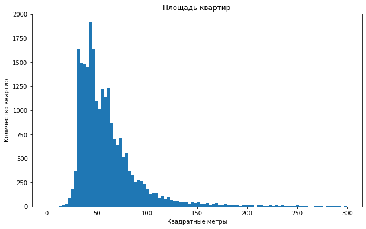

```
count    23613.000000
mean        60.340678
std         35.648988
min         12.000000
25%         40.000000
50%         52.000000
75%         69.800000
max        900.000000
Name: total_area, dtype: float64
```

```python
plt.figure(figsize=(10, 6))
plt.hist(data['total_area'], bins=100, range=(0, 300))
plt.title('Площадь квартир')
plt.xlabel('Квадратные метры')
plt.ylabel('Количество квартир')
plt.show()

# описательная статистика
print(data['total_area'].describe())
```

Теперь проанализируем жилую площадь. Большинство значений у нас от 18 до 41. Но есть и аномальные значения. Напомню, к жилой площади относятся только те помещения, которые пригодны для проживания: гостиная, спальня, детская. Сюда не относятся: кухня, санузлы, коридор, кладовые и гардеробные. У нас же минимальное значение 2. Проверила, дважды упоминается 2м и дважды 3м. В масштабах выборки это незначительно.

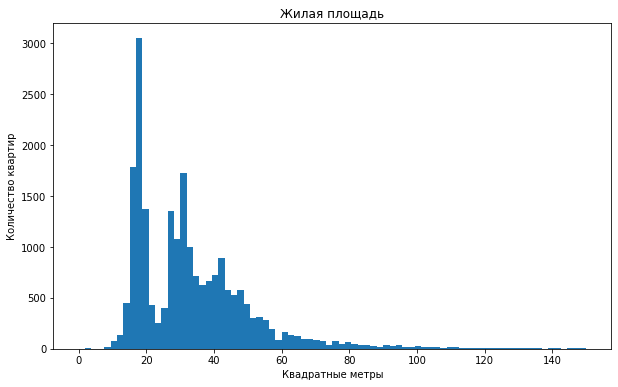

```
count    21743.000000
mean        34.462781
std         22.037433
min          2.000000
25%         18.600000
50%         30.000000
75%         42.300000
max        409.700000
Name: living_area, dtype: float64
```

```python
plt.figure(figsize=(10, 6))
plt.hist(data['living_area'], bins = 80, range = (0,150))
plt.title('Жилая площадь')
plt.xlabel('Квадратные метры')
plt.ylabel('Количество квартир')
plt.show()
data['living_area'].describe()
```

```python
data['living_area'].sort_values()
```

```
21758    2.0
13915    2.0
3242     3.0
23574    3.0
17582    5.0
        ...
23642    NaN
23663    NaN
23670    NaN
23679    NaN
23697    NaN
Name: living_area, Length: 23613, dtype: float64
```

Проанализируем площадь кухни. В среднем кухни от 7 до 11 квадратных метров.

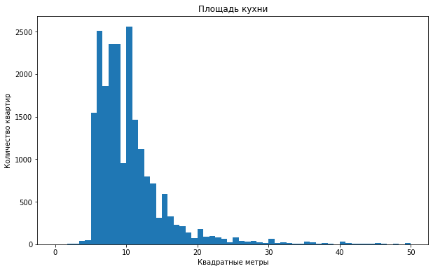

```
count    21382.000000
mean        10.564128
std          5.904316
min          1.300000
25%          7.000000
50%          9.100000
75%         12.000000
max        112.000000
Name: kitchen_area, dtype: float64
```

```python
plt.figure(figsize=(10, 6))
plt.hist(data['kitchen_area'], bins = 60, range = (0,50))
plt.title('Площадь кухни')
plt.xlabel('Квадратные метры')
plt.ylabel('Количество квартир')
plt.show()
data['kitchen_area'].describe()
```

На очереди анализ цены объекта, одной из важнейших характеристик. У нас довольно большой хвост в сторону высоких значений. Посмотрю также распределение значений по убыванию. Максимальное значение сильно выделяется. Но такое реально может быть, рынок недвижимости очень разнообразен. Большая часть квартир относится к диапазону цен от 3.4 млн до 6.8 млн.

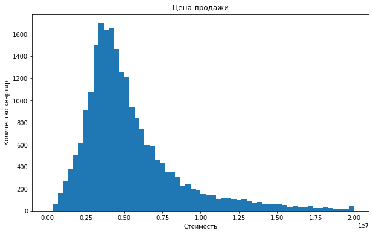

```
count    2.361300e+04
mean     6.540555e+06
std      1.090172e+07
min      1.219000e+04
25%      3.400000e+06
50%      4.650000e+06
75%      6.799000e+06
max      7.630000e+08
Name: last_price, dtype: float64
```

```python
plt.figure(figsize=(10, 6))
plt.hist(data['last_price'], bins = 60, range = (0,20000000))
plt.title('Цена продажи')
plt.xlabel('Стоимость')
plt.ylabel('Количество квартир')
plt.show()
data['last_price'].describe()
```

```python
data['last_price'].sort_values(ascending=False).head(10)
```

```
12971    763000000
19540    420000000
14706    401300000
1436     330000000
15651    300000000
22831    289238400
16461    245000000
13749    240000000
5893     230000000
8900     190870000
Name: last_price, dtype: int64
```

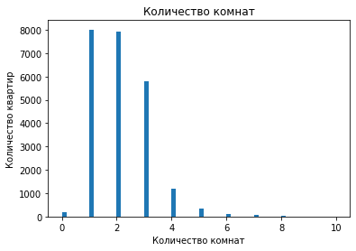

```
count    23613.000000
mean         2.071147
std          1.078380
min          0.000000
25%          1.000000
50%          2.000000
75%          3.000000
max         19.000000
Name: rooms, dtype: float64
```

```python
plt.hist(data['rooms'], bins = 60, range = (0,10))
plt.title('Количество комнат')
plt.xlabel('Количество комнат')
plt.ylabel('Количество квартир')
plt.show()
data['rooms'].describe()
```

```python
data['rooms'].value_counts()
```

```
1     8015
2     7913
3     5795
4     1177
5      325
0      194
6      104
7       59
8       12
9        8
10       3
11       2
14       2
19       1
16       1
12       1
15       1
Name: rooms, dtype: int64
```

```python
data['studio'].value_counts()
```

```
False    23467
True       146
Name: studio, dtype: int64
```

Теперь высота потолков. Пик приходится на 2.65, которым я заполнила пропуски. В дальнейшем анализе нам не нужна эта информация, так что оставим.

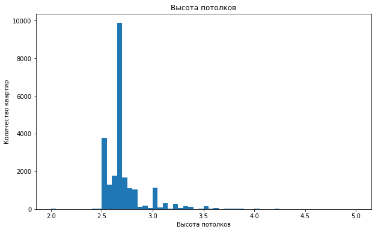

```
count    23613.000000
mean         2.724581
std          0.990085
min          1.000000
25%          2.600000
50%          2.650000
75%          2.700000
max        100.000000
Name: ceiling_height, dtype: float64
```

```python
plt.figure(figsize=(10, 6))
plt.hist(data['ceiling_height'], bins = 60, range = (2,5))
plt.title('Высота потолков')
plt.xlabel('Высота потолков')
plt.ylabel('Количество квартир')
plt.show()
data['ceiling_height'].describe()
```

Приступим к анализу этажей:

- этаж квартиры;

Преимущественно до пятого, распределение Пуассона

- тип этажа квартиры («первый», «последний», «другой»);

Большинство квартир находились не на первом и не на последнем этаже

- общее количество этажей в доме;

Очень много пяти- и девятиэтажных домов

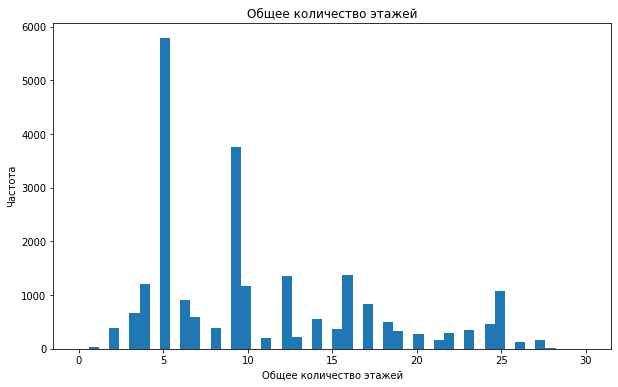

```
count    23613.000000
mean        10.673824
std          6.597173
min          1.000000
25%          5.000000
50%          9.000000
75%         16.000000
max         60.000000
Name: floors_total, dtype: float64
```

```python
plt.figure(figsize=(10, 6))
plt.hist(data['floors_total'], bins = 50, range = (0,30))
plt.title('Общее количество этажей')
plt.xlabel('Общее количество этажей')
plt.ylabel('Частота')
plt.show()
data['floors_total'].describe()
```

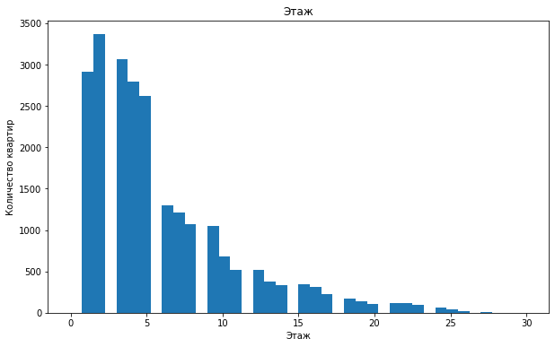

```
count    23613.000000
mean         5.877313
std          4.873539
min          1.000000
25%          2.000000
50%          4.000000
75%          8.000000
max         33.000000
Name: floor, dtype: float64
```

```python
plt.figure(figsize=(10, 6))
plt.hist(data['floor'], bins = 40, range = (0,30))
plt.title('Этаж')
plt.xlabel('Этаж')
plt.ylabel('Количество квартир')
plt.show()
data['floor'].describe()
```

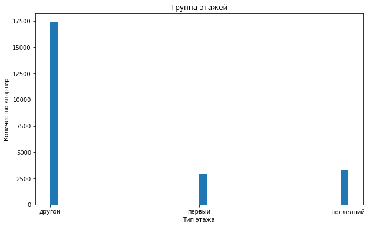

```
другой       17363
последний     3336
первый        2914
Name: floor_group, dtype: int64
```

```python
plt.figure(figsize=(10, 6))
plt.hist(data['floor_group'], bins = 40)
plt.title('Группа этажей')
plt.xlabel('Тип этажа')
plt.ylabel('Количество квартир')
plt.show()

data['floor_group'].value_counts()
```

Теперь рассмотрим:

- расстояние до центра города в метрах;

Большинство квартир находятся не в центре, а на расстоянии 9-16м от него

- расстояние до ближайшего парка;

Всего 300-600м и вы в любимом парке!

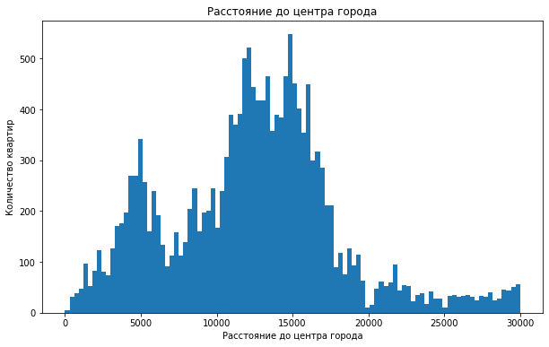

```
count    18104.000000
mean     14185.084015
std       8614.132292
min        181.000000
25%       9233.750000
50%      13093.000000
75%      16287.000000
max      65968.000000
Name: cityCenters_nearest, dtype: float64
```

```python
plt.figure(figsize=(10, 6))
plt.hist(data['cityCenters_nearest'], bins = 100, range = (0,30000))
plt.title('Расстояние до центра города')
plt.xlabel('Расстояние до центра города')
plt.ylabel('Количество квартир')
plt.show()
data['cityCenters_nearest'].describe()
```

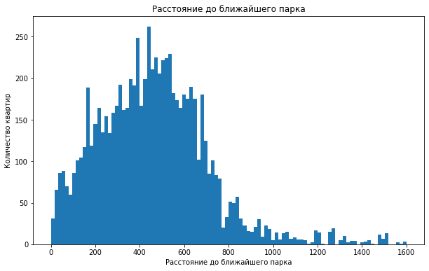

```
count    8045.000000
mean      490.554630
std       341.336698
min         1.000000
25%       288.000000
50%       455.000000
75%       612.000000
max      3190.000000
Name: parks_nearest, dtype: float64
```

```python
plt.figure(figsize=(10, 6))
plt.hist(data['parks_nearest'], bins = 100, range = (0,1600))
plt.title('Расстояние до ближайшего парка')
plt.xlabel('Расстояние до ближайшего парка')
plt.ylabel('Количество квартир')
plt.show()
data['parks_nearest'].describe()
```

**Выводы:** Общая площадь: основная масса значений лежит от 25 до 70

Жилая площадь: большинство значений у нас от 18 до 41

Площадь кухни: в среднем от 7 до 11 квадратов

Большая часть квартир относится к диапазону цен от 3.4 млн до 6.8 млн.

Как нам показывала площадь квартир, большинство относятся к 1-2 комнатным. 3 комнатных тоже достаточно много, остальные же варианты менее распространены.

Высота потолков: пик приходится на 2.65

Этаж квартиры: преимущественно до пятого, распределение Пуассона

Тип этажа квартиры («первый», «последний», «другой»): большинство находились не на первом и не на последнем этаже

Общее количество этажей в доме: очень много пяти- и девятиэтажных домов, но и более высокие умеренно распространены

## шаг. Как быстро продавались квартиры.

```
count    20441.000000
mean       180.884839
std        219.685543
min          1.000000
25%         45.000000
50%         95.000000
75%        232.000000
max       1580.000000
Name: days_exposition, dtype: float64
```

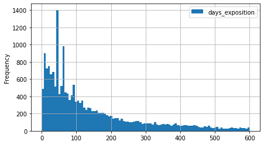

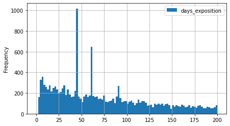

```python
data.plot(y = 'days_exposition', kind = 'hist', bins=100, grid=True, figsize = (7,4), range=(0,600))
data.plot(y = 'days_exposition', kind = 'hist', bins=100, grid=True, figsize = (7,4), range=(0,200))
data['days_exposition'].describe()
```

Теперь выясним, какие факторы больше всего влияют на стоимость объекта? Изучим, зависит ли цена от:

- общей площади;
- жилой площади;
- площади кухни;
- количества комнат;
- этажа, на котором расположена квартира (первый, последний, другой);
- даты размещения (день недели, месяц, год).

Построим графики, которые покажут зависимость цены от указанных выше параметров. Для подготовки данных перед визуализацией буду использовать сводные таблицы. Для начала уберу из рассматриваемых столбцов аномальные значения, то есть не входящие в межквартильный размах.

```python
def quartile_range(df,column):
    quartiles = df[column].quantile([0.25, 0.75])
    iqr = quartiles[0.75] - quartiles[0.25]
    normal_values = df.loc[(df[column] < quartiles[0.75] + 1.5*iqr) & (df[column] > quartiles[0.25] - 1.5*iqr), column]
    return normal_values
```

```python
list = ['last_price', 'total_area', 'kitchen_area', 'living_area', 'rooms', 'ceiling_height']
for column in list:
    data[column] = quartile_range(data, column)
```

```
Коэффициент корреляции: 0.6943047373182962
```

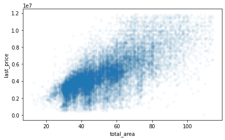

```python
print('Коэффициент корреляции:', data['last_price'].corr(data['total_area']))
data.plot(x='total_area', y='last_price', kind='scatter', alpha=0.03, figsize = (7,4));
```

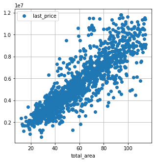

```python
data.pivot_table(index = 'total_area', values = 'last_price', aggfunc = 'median').plot(grid=True, style='o', figsize=(5, 5));
```

Иногда нужно проверять и очевидные факты. Площадь квартиры и её стоимость сильно коррелируют. Чем больше площадь, тем выше стоимость.

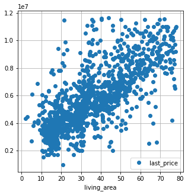

```python
data.pivot_table(index = 'living_area', values = 'last_price', aggfunc = 'median').plot(grid=True, style='o', figsize=(5, 5));
```

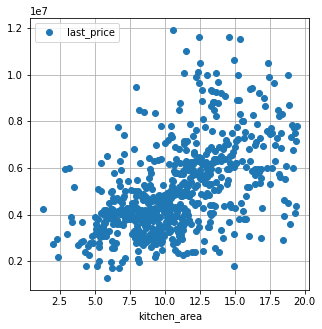

```python
data.pivot_table(index = 'kitchen_area', values = 'last_price', aggfunc = 'median').plot(grid=True, style='o', figsize=(5, 5));
```

Стоимость квартиры также коррелирует с жилой площадью. С кухней тоже есть связь, но менее выраженная. Я думаю, что оба этих значения проистекают из их связи жилой и кухонной пллощадей с общей площадью.

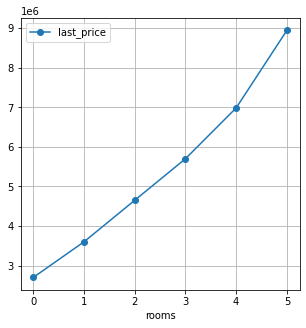

```python
data.pivot_table(index = 'rooms', values = 'last_price', aggfunc = 'median').plot(grid=True, style='-o', figsize=(5, 5));
```

Чем больше комнат, тем дороже квартира.

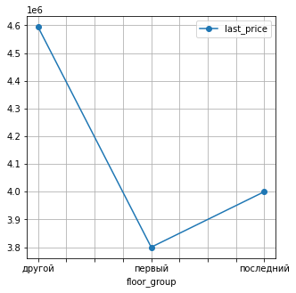

```python
data.pivot_table(index = 'floor_group', values = 'last_price', aggfunc = 'median').plot(grid=True, style='-o', figsize=(5, 5));
```

Квартиры на первом этаже стоят дешевле всего. Последний этаж стоит дороже, чем первый, но ниже, чем другие.

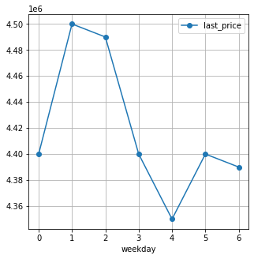

```python
data.pivot_table(index = 'weekday', values = 'last_price', aggfunc = 'median').plot(grid=True, style='-o', figsize=(5, 5));
```

Самые дорогие квартиры публикуются во вторник-среду. В пятницу же минимальное значение.

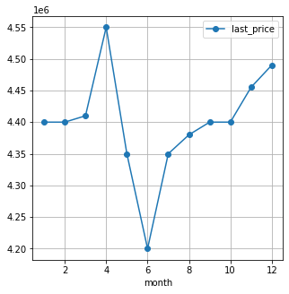

```python
data.pivot_table(index = 'month', values = 'last_price', aggfunc = 'median').plot(grid=True, style='-o', figsize=(5, 5));
```

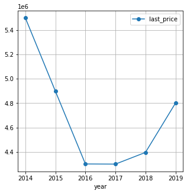

```python
data.pivot_table(index = 'year', values = 'last_price', aggfunc = 'median').plot(grid=True, style='-o', figsize=(5, 5));
```

Проанализируем зависимость от месяца и года. Пик продаж приходится на апрель, после чего сильно проседает рынок в июне. И плавно восстанавливается. С октября по декабрь тоже высокие значения.

По годам, пик был в 2014 с тех пор показателли значительно упали, достингнув нижней отметки в 2016. Однако уже с 2017 начался рост, хотя прежние показатели не были достигнуты.

Посчитаем среднюю цену одного квадратного метра в 10 населённых пунктах с наибольшим числом объявлений

Самая низкая (из выборки в 10 населенных пунктов) стоимость квадратного метра в Выборге

| locality_name | meter_price |
| --- | --- |
| посёлок Парголово | 199500 |
| Санкт-Петербург | 189048 |
| деревня Кудрово | 185655 |
| Пушкин | 181392 |
| посёлок Мурино | 172446 |
| посёлок Шушары | 144545 |
| Колпино | 125677 |
| Всеволожск | 124137 |
| Гатчина | 116719 |
| Выборг | 92000 |

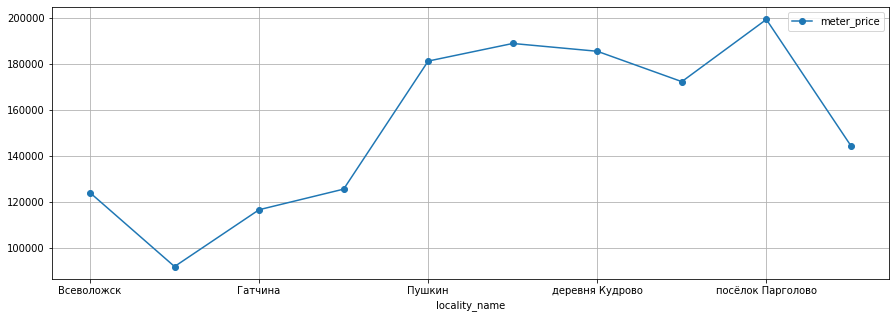

```python
name_meter = data['locality_name'].value_counts().head(10)
name_meter_table = data.query('locality_name in (@name_meter.index)').pivot_table(values='meter_price', index='locality_name', aggfunc='median').plot(grid=True, style='-o', figsize=(15, 5))
name_meter_table = data.query('locality_name in (@name_meter.index)').pivot_table(values='meter_price', index='locality_name', aggfunc='median')
name_meter_table = name_meter_table.astype(int)

name_meter_table.sort_values('meter_price', ascending=False)
```

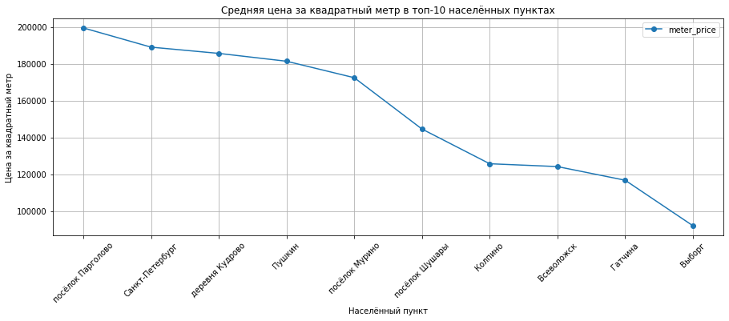

```python
name_meter_table = data.query('locality_name in (@name_meter.index)').pivot_table(values='meter_price', index='locality_name', aggfunc='median')
name_meter_table = name_meter_table.astype(int).sort_values('meter_price', ascending=False)

ax = name_meter_table.plot(grid=True, style='-o', figsize=(15, 5))
ax.set_xticks(range(len(name_meter_table.index)))
ax.set_xticklabels(name_meter_table.index, rotation=45)
ax.set_title("Средняя цена за квадратный метр в топ-10 населённых пунктах")
ax.set_ylabel("Цена за квадратный метр")
ax.set_xlabel("Населённый пункт")
```

Ранее мы посчитали расстояние до центра в километрах. Теперь выделим квартиры в Санкт-Петербурге с помощью столбца locality_name и вычислим среднюю цену каждого километра.

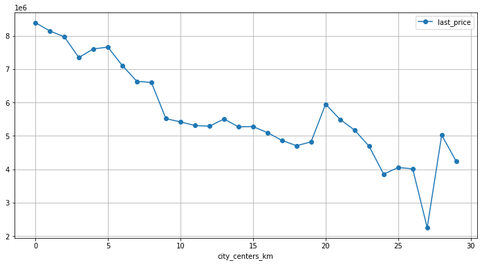

```python
data.query('locality_name == "Санкт-Петербург"').pivot_table(index='city_centers_km', values='last_price').plot(style='-o', grid=True, figsize=(12, 6));
```

#### Вывод:

Площадь квартиры и её стоимость сильно коррелируют. Чем больше площадь, тем выше стоимость. Это также влияет на корреляцию стоимости с жилой площадью. С кухней есть связь, но менее выраженная Чем больше комнат, тем дороже квартира. Квартиры на первом этаже стоят дешевле всего. Последний этаж стоит дороже, чем первый, но дешевле, чем другие. Самые дорогие квартиры публикуются во вторник-среду. В пятницу же минимальное значение. У продажи квратир есть сезонность. Пик продаж приходится на апрель, после чего сильно проседает рынок в июне. И плавно восстанавливается. С октября по декабрь тоже высокие значения. По годам, пик был в 2014 с тех пор показатели значительно упали, достингнув нижней отметки в 2016. Однако уже с 2017 начался рост, хотя прежние показатели не были достигнуты.

## шаг. Общий вывод

Общая площадь: основная масса значений лежит от 25 до 70

Жилая площадь: большинство значений у нас от 18 до 41

Площадь кухни: в среднем от 7 до 11 квадратов

Большая часть квартир относится к диапазону цен от 3.4 млн до 6.8 млн.

Как нам показывала площадь квартир, большинство относятся к 1-2 комнатным. 3 комнатных тоже достаточно много, остальные же варианты менее распространены.

Высота потолков: пик приходится на 2.65

Этаж квартиры: преимущественно до пятого, распределение Пуассона

Тип этажа квартиры («первый», «последний», «другой»): большинство находились не на первом и не на последнем этаже

Общее количество этажей в доме: очень много пяти- и девятиэтажных домов, но и более высокие умеренно распространены

Площадь квартиры и её стоимость сильно коррелируют. Чем больше площадь, тем выше стоимость. Это также влияет на корреляцию стоимости с жилой площадью. С кухней есть связь, но менее выраженная Чем больше комнат, тем дороже квартира. Квартиры на первом этаже стоят дешевле всего. Последний этаж стоит дороже, чем первый, но дешевле, чем другие. Самые дорогие квартиры публикуются во вторник-среду. В пятницу же минимальное значение. У продажи квратир есть сезонность. Пик продаж приходится на апрель, после чего сильно проседает рынок в июне. И плавно восстанавливается. С октября по декабрь тоже высокие значения. По годам, пик был в 2014 с тех пор показатели значительно упали, достингнув нижней отметки в 2016. Однако уже с 2017 начался рост, хотя прежние показатели не были достигнуты.